# **Facial Emotion Detection**

## **Executive summary**

The Facial Emotion Recognition Project aims to develop a robust neural network model capable of accurately detecting and classifying emotions from facial images into one of four emotions, Happy, Neutral, Sad and Surprise. Emotion recognition has wide-ranging applications across various industries, including healthcare, marketing, and human-computer interaction.

The project began with **augmenting the pre-collected data**, including gathering a diverse dataset of facial images representing the four different emotions. Augmenting techniques were applied to the data to shear, flip and resize the images for better training.

Next, a **Convolutional Neural Network (CNN) architecture** was designed and trained using the preprocessed dataset. The CNN model leverages the spatial hierarchies present in facial images to automatically learn discriminative features for emotion classification. Training the model involved optimizing hyperparameters, such as learning rate, batch size, and network architecture, to achieve the best performance. Performance was measured using the training and validation **accuracy** which was simultaneous to the training

After training, **test** datasets were used to assess its accuracy, precision, recall and F1-score. The confusion matrix was plotted to compare the actual and predicted results

In conclusion, the Facial Emotion Recognition Project represents a significant advancement in leveraging artificial intelligence for emotion analysis from facial expressions. By accurately detecting and classifying emotions, the model opens up opportunities for improving human-computer interaction, personalized marketing strategies, mental health assessment, and more. Continued research and development in this field have the potential to unlock even greater value and impact in the future.

**Out of all the different models and their variants tested, it is found that Model 3 performs the best in terms of:**

**-Training accuracy - 72%**

**-Validation accuracy - 71%**

**-Test accuracy -77%**

**-Average F1 score (among 4 classes)-76%**

## **Mounting the Drive**

```python
#mounting drive on google colab
from google.colab import drive
drive.mount("/content/drive/")
```

## **Importing the Libraries**

```python
#importing basic libraries
import numpy as np
import pandas as pd
import matplotlib.pyplot as plt
import os
import zipfile
import seaborn as sns

#For images and GUI
import cv2
from IPython.display import Image
import ipywidgets as widgets
from PIL import Image
from IPython.display import display

#For ModelBuilding
import tensorflow as tf
import keras
from tensorflow.keras.models import Sequential,Model
from tensorflow.keras.layers import Dense,Conv2D,MaxPooling2D,Flatten,BatchNormalization,Activation,LeakyReLU,Dropout
from tensorflow.keras import backend,losses,optimizers
from tensorflow.keras.utils import to_categorical
from tensorflow.keras.optimizers import Adam,SGD
from tensorflow.keras.callbacks import EarlyStopping,ModelCheckpoint
from tensorflow.keras.preprocessing.image import load_img,ImageDataGenerator
from tensorflow.keras.regularizers import l2
from google.colab.patches import cv2_imshow

#For evaluating performance
from sklearn.metrics import classification_report,confusion_matrix,f1_score,accuracy_score

#to access the model
from keras.models import load_model
```

```python
tf.random.set_seed(42)
```

### **Let us load and unzip the data**

```python
#unzipping folder
with zipfile.ZipFile('/content/drive/MyDrive/Capstone Project/Facial_emotion_images.zip','r') as zipref:
  zipref.extractall()
```

## **Visualizing our Classes**

Let's look at our classes.

### **Happy**

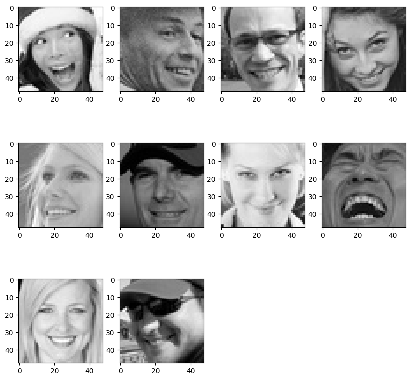

```python
#visualising first 10 images in folder "happy"
path='Facial_emotion_images/'           #saving the path of the images extracted from the zipped folder
expression1='happy'

fig=plt.figure(figsize=(10,10))         #plotting the images
for i in range(1,11):                   #creating a loop to show the first 10 images in the folder
  ax=fig.add_subplot(3,4,i)
  img=load_img(path+'train/'+expression1+'/'+os.listdir(path+'train/'+expression1)[i],target_size=(48,48))   #loading image into img
  plt.imshow(img)
```

**Observations and Insights : These are gray scale images of happy faces clicked from many different angles. The common factor is that the lips are curved and there are lines on the cheek muscles. The teeth may or may not be showed**

### **Neutral**

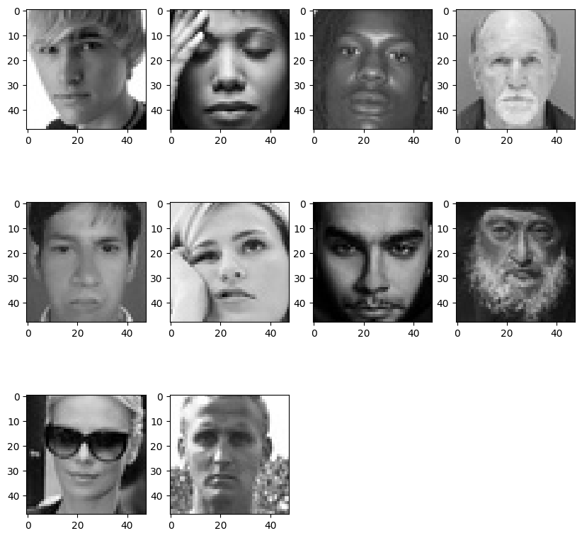

```python
#visualising first 10 images in folder "Neutral"
expression2='neutral'

fig=plt.figure(figsize=(10,10))

for i in range(1,11):
  ax=fig.add_subplot(3,4,i)
  img=load_img(path+'train/'+expression2+'/'+os.listdir(path+'train/'+expression2)[i],target_size=(48,48))
  plt.imshow(img)
```

**Observations and Insights:Gray scale images of faces showning no prominent emotion. No specific feature to learn from.**

### **Sad**

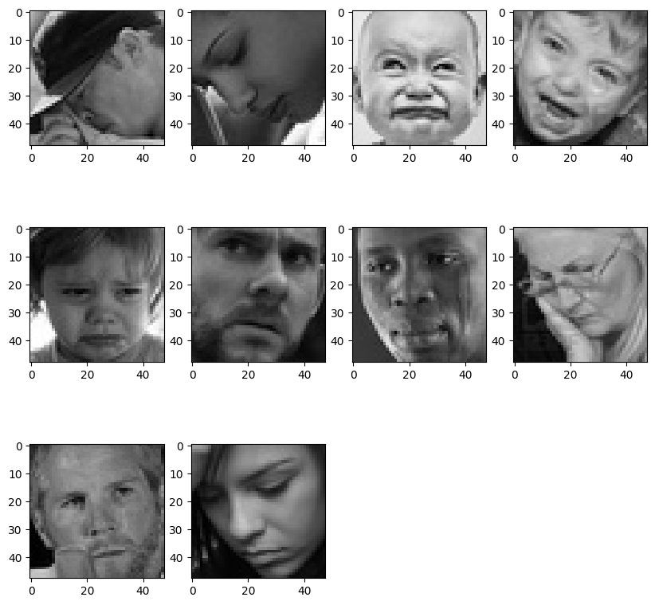

```python
#visualising first 10 images in folder "sad"
expression3='sad'

fig=plt.figure(figsize=(10,10))

for i in range(1,11):
  ax=fig.add_subplot(3,4,i)
  img=load_img(path+'train/'+expression3+'/'+os.listdir(path+'train/'+expression3)[i],target_size=(48,48))
  plt.imshow(img)
```

**Observations and Insights: Sad or angry images with most faces having lips tightened or curved downward. For the others, its hard to differentiate with neutral**

### **Surprised**

[figure not shown]

```python
#visualising first 10 images in folder "surprise"
expression4='surprise'

fig=plt.figure(figsize=(10,10))

for i in range(1,11):
  ax=fig.add_subplot(3,4,i)
  img=load_img(path+'train/'+expression4+'/'+os.listdir(path+'train/'+expression4)[i],target_size=(48,48))
  plt.imshow(img)
```

**Observations and Insights:Easily predictable with eyes rolled, mouths open,eyebrows raised**

## **Checking Distribution of Classes**

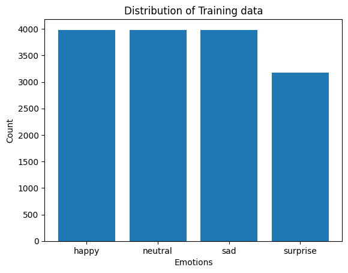

```python
#accessing the respective 'train' folder to count the number of images in each expression
train_count_happy=len(os.listdir(path+'train'+'/'+expression1))
train_count_neutral=len(os.listdir(path+'train'+'/'+expression2))
train_count_sad=len(os.listdir(path+'train'+'/'+expression3))
train_count_surprise=len(os.listdir(path+'train'+'/'+expression4))

emotions=['happy',"neutral","sad","surprise"]  #creating an array of emotions
train_count=[train_count_happy,train_count_neutral,train_count_sad,train_count_surprise] #creating an array of emotions

#plotting the two on a bar chart
plt.bar(emotions,train_count)
plt.title("Distribution of Training data")
plt.xlabel('Emotions')
plt.ylabel('Count')
```

**Observations and Insights:Though it looks there are fewer images in the 'Surprise' class, it does'nt look like it would affect the training process as after visualisation, it looked like the 'Surprise' images are easily predictable**

## **Creating our Data Loaders**

```python
#Creating an Image Data Generator object with rescaling, shearing and horizontal flip features
datagen = ImageDataGenerator(
    rescale=1./255,
    shear_range=0.3,
    horizontal_flip=True,
   )
#using the Image Data Generator object to save the train images in grayscale to train_data
train_data=datagen.flow_from_directory(
    path+'train',
    color_mode='grayscale',
    target_size=(48,48),
    batch_size=32,shuffle=True)
```

```
Found 15109 images belonging to 4 classes.
```

```python
#using the Image Data Generator object to save the validation images in grayscale to validation__data
validation_data=datagen.flow_from_directory(
    path+'validation',
    color_mode='grayscale',
    target_size=(48,48),
    batch_size=32)
```

```
Found 4977 images belonging to 4 classes.
```

```python
#using the Image Data Generator object to save the test images in grayscale to test_data
test_data=datagen.flow_from_directory(
    path+'test',
    color_mode='grayscale',
    target_size=(48,48),
    batch_size=32)

#Creating empty test images and labels arrays to save the images and labels after iterating over test_data
test_images = []
test_labels = []

# Iterate over test_data to access images and labels separately
for i in range(len(test_data)):
    batch_images, batch_labels = next(test_data)
    test_images.extend(batch_images)
    test_labels.extend(batch_labels)
```

```
Found 128 images belonging to 4 classes.
```

## **Problem and solution summary**

### **Summary of the problem**

Recognising facial emotions is important to understand human behaviour, to ease human-computer interaction, in healthcare especially mental health conditions, security and surveillance to detect abnormal behaviour, in education for assessing student behaviour and enhance learning outcomes. It can also be used in market research and advertising to understand customer experience. Due to these widespread business implications, this is an important problem to solve. **Our problem here is to develop a deep learning model that can predict the emotion in an image as one of 'Happy', 'Neutral', 'Sad', 'Surprise'.**

### **Solution Summary**

After unzipping and extracting the images, few of the images from each class were viewed and the distribtution of the classes plotted. It was found that there was a slight imbalance in the classes. The 'Surprise' was found to have fewer number of images. This was ignored as it didn't pose a serious threat to the performance.

4 types of models were designed,trained and tested:

-**Basic-A model with a minimum number of Convolutional and fully connected layers was designed and tested. Of the RGB and grayscale models trained and tested,grayscale performed better**

-**This basic grayscale model was improved by adding dropout layers and batch normalization to combat overfitting**

-**Transfer learning models, VGG16,ResNet and EfficientNet models were combined with RGB input layers, of which ResNet performed the best. This model did not have an accuracy comparable to the improved basic model that was developed earlier. It was concluded that transfer learning models worl best when the input images are RGB as they are designed for RGB images**

-**A deeper Neural Network with more number of Conv2D layers was designed with grayscale input, trained and tested. This model gave the best accuracy. The CNN model was chosen as the final model as it was found to have:**

**-Higher training accuracy**

**-Higher training accuracy**

**-Reduced overfitting**

**-Comparativerly lower confusion between the emotions, especially 'Sad' and 'Neutral'**

**-Higher F1 score for all classes**

### Performance comparison

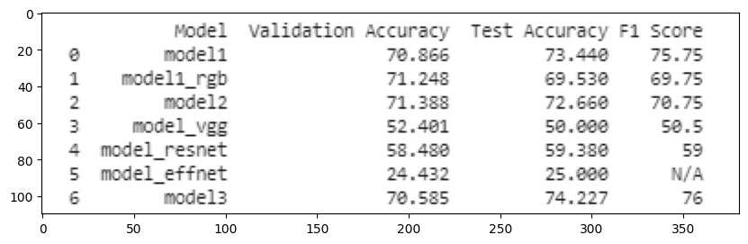

```python
fig=plt.figure(figsize=(10,10))
img=load_img('/content/performance table comparison.png')
plt.imshow(img)
```

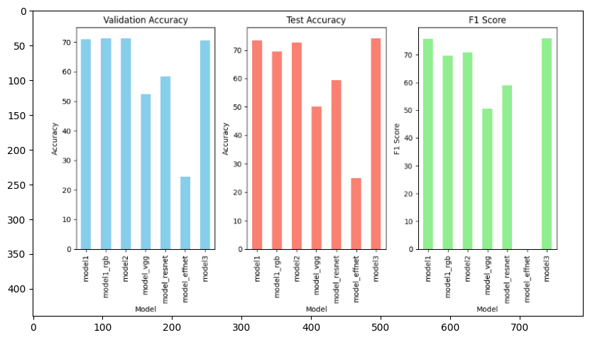

```python
fig=plt.figure(figsize=(10,10))
img=load_img('/content/performance graph comparison.png')
plt.imshow(img)
```

## **Building a Complex Neural Network Architecture**

The best performing model building details can be found below:

### **Model Building**

Model 3 specifications are as follows:

First Convolutional Layer with 32 filters, kernel size=4, padding='same' and input_shape=(48,48,1) for grayscale input and activation='relu'

Second Convolutional Layer with 32 filters, kernel size=4, padding='same' and activation='relu'

Third Convolutional Layer with 64 filters, kernel size=4, padding='same' and activation='relu'

Fourth Convolutional Layer with 64 filters, kernel size=4, padding='same' and activation='relu'

Fifth Convolutional Layer with 64 filters, kernel size=4, padding='same' and activation='relu'

Sixth Convolutional Layer with 64 filters, kernel size=4, padding='same' and activation='relu'

Maxpooling layer of 2,2

Seventh Convolutional Layer with 128 filters, kernel size=4, padding='same' and activation='relu'

Eighth Convolutional Layer with 128 filters, kernel size=4, padding='same' and activation='relu'

Ninth Convolutional Layer with 128 filters, kernel size=4, padding='same' and activation='relu'

Tenth Convolutional Layer with 128 filters, kernel size=4, padding='same' and activation='relu'

Maxpooling layer of 2,2

Eleventh Convolutional Layer with 256 filters, kernel size=4, padding='same' and activation='relu'

Twelfth Convolutional Layer with 256 filters, kernel size=4, padding='same' and activation='relu'

Thirteenth Convolutional Layer with 256 filters, kernel size=4, padding='same' and activation='relu'

Fourteenth Convolutional Layer with 256 filters, kernel size=4, padding='same' and activation='relu'

Maxpooling layer of 2,2

Flatten()

First dropout layer with rate=0.2

BatchNormalization

Dense layer with 32 nodes and activation='relu'

Second dropout layer with rate=0.2

BatchNormalization

Dense layer with 32 nodes and activation='relu'

Dense layer with 4 output nodes with activation='Softmax' for the 4 different emotions to be predicted

The model was compiled with Adam Optimizer with a learning rate of 0.001

```python
model3=Sequential()

model3.add(Conv2D(32,(4,4),activation='relu',padding='same',input_shape=(48,48,1)))  #moving ahead with grayscale inputs as RGB didnt show much big of a difference
model3.add(Conv2D(32,(4,4),activation='relu',padding='same'))

model3.add(Conv2D(64,(4,4),padding='same',activation='relu'))                        #removed maxpooling layers
model3.add(Conv2D(64,(4,4),padding='same',activation='relu'))                        #2 layers of conv2D with 64 filters and kernel size increased to (4,4) to capture bigger details


model3.add(Conv2D(64,(4,4),padding='same',activation='relu'))                        #removed maxpooling layers
model3.add(Conv2D(64,(4,4),padding='same',activation='relu'))                        #2 layers of conv2D with 64 filters and kernel size increased to (4,4) to capture bigger details
model3.add(MaxPooling2D(2,2))

model3.add(Conv2D(128,(4,4),padding='same',activation='relu'))                       #2 layers of conv2D with 128 filters
model3.add(Conv2D(128,(4,4),padding='same',activation='relu'))


model3.add(Conv2D(128,(4,4),padding='same',activation='relu'))                       #2 layers of conv2D with 128 filters
model3.add(Conv2D(128,(4,4),padding='same',activation='relu'))
model3.add(MaxPooling2D(2,2))

model3.add(Conv2D(256,(4,4),padding='same',activation='relu'))                       #2 layers of conv2D with 256 filters
model3.add(Conv2D(256,(4,4),padding='same',activation='relu'))


model3.add(Conv2D(256,(4,4),padding='same',activation='relu'))                       #2 layers of conv2D with 256 filters
model3.add(Conv2D(256,(4,4),padding='same',activation='relu'))
model3.add(MaxPooling2D(2,2))

model3.add(Flatten())

model3.add(Dropout(0.2))                                              #to correct the overfitting that may be caused
model3.add(BatchNormalization())

model3.add(Dense(32,activation='relu'))
model3.add(Dropout(0.2))                                              #to correct the overfitting that may be caused
model3.add(BatchNormalization())

model3.add(Dense(32,activation='relu'))

model3.add(Dense(4,activation="Softmax"))

model3.summary()
```

```
Model: "sequential"
_________________________________________________________________
 Layer (type)                Output Shape              Param #
=================================================================
 conv2d (Conv2D)             (None, 48, 48, 32)        544

 conv2d_1 (Conv2D)           (None, 48, 48, 32)        16416

 conv2d_2 (Conv2D)           (None, 48, 48, 64)        32832

 conv2d_3 (Conv2D)           (None, 48, 48, 64)        65600

 conv2d_4 (Conv2D)           (None, 48, 48, 64)        65600

 conv2d_5 (Conv2D)           (None, 48, 48, 64)        65600

 max_pooling2d (MaxPooling2  (None, 24, 24, 64)        0
 D)

 conv2d_6 (Conv2D)           (None, 24, 24, 128)       131200

 conv2d_7 (Conv2D)           (None, 24, 24, 128)       262272

 conv2d_8 (Conv2D)           (None, 24, 24, 128)       262272

 conv2d_9 (Conv2D)           (None, 24, 24, 128)       262272

 max_pooling2d_1 (MaxPoolin  (None, 12, 12, 128)       0
 g2D)

 conv2d_10 (Conv2D)          (None, 12, 12, 256)       524544

 conv2d_11 (Conv2D)          (None, 12, 12, 256)       1048832

 conv2d_12 (Conv2D)          (None, 12, 12, 256)       1048832

 conv2d_13 (Conv2D)          (None, 12, 12, 256)       1048832

 max_pooling2d_2 (MaxPoolin  (None, 6, 6, 256)         0
 g2D)
```

[output cut: 9 more lines]

```

 dropout_1 (Dropout)         (None, 32)                0

 batch_normalization_1 (Bat  (None, 32)                128
 chNormalization)

 dense_1 (Dense)             (None, 32)                1056

 dense_2 (Dense)             (None, 4)                 132

=================================================================
Total params: 5168772 (19.72 MB)
Trainable params: 5150276 (19.65 MB)
Non-trainable params: 18496 (72.25 KB)
_________________________________________________________________
```

### **Model Architecture**

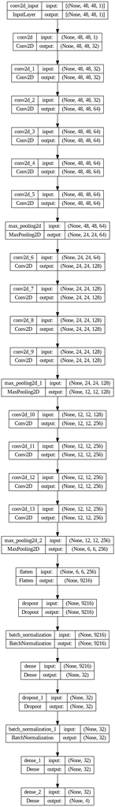

```python
#plotting the model to get a pictorial representation of the model
from tensorflow.keras.utils import plot_model
from tensorflow.keras.models import Model


plot_model(model3, to_file='model_architecture.png', show_shapes=True, show_layer_names=True)
```

### **Compiling and Training the Model**

```python
opt=Adam(learning_rate=0.001)
model3.compile(optimizer=opt,loss='categorical_crossentropy',metrics=['accuracy'])
```

```python
es3=EarlyStopping(monitor='val_accuracy',
                 patience=5,
                 mode='auto',
                 verbose=1)
mc3=ModelCheckpoint("best_model3",
                   monitor='val_accuracy',
                   verbose=1,
                   save_best_only=True,
                   save_weights_only=False,
                   mode='auto',
                   save_freq='epoch')
class_weights={0:1,1:2,2:2,3:1}
```

```python
history3=model3.fit(train_data,
                    validation_data=validation_data,
                    epochs=20,
                    callbacks=[es3,mc3],
                    class_weight=class_weights)
```

```
Epoch 1: val_accuracy improved from -inf to 0.45509, saving model to best_model3
Epoch 2: val_accuracy improved from 0.45509 to 0.67631, saving model to best_model3
Epoch 3: val_accuracy improved from 0.67631 to 0.68917, saving model to best_model3
Epoch 4: val_accuracy improved from 0.68917 to 0.69982, saving model to best_model3
Epoch 5: val_accuracy did not improve from 0.69982
Epoch 6: val_accuracy did not improve from 0.69982
Epoch 7: val_accuracy improved from 0.69982 to 0.71549, saving model to best_model3
Epoch 8: val_accuracy did not improve from 0.71549
Epoch 9: val_accuracy did not improve from 0.71549
Epoch 10: val_accuracy did not improve from 0.71549
Epoch 11: val_accuracy did not improve from 0.71549
Epoch 12: val_accuracy did not improve from 0.71549
Epoch 12: early stopping
```

### Training vs Validation Accuracy

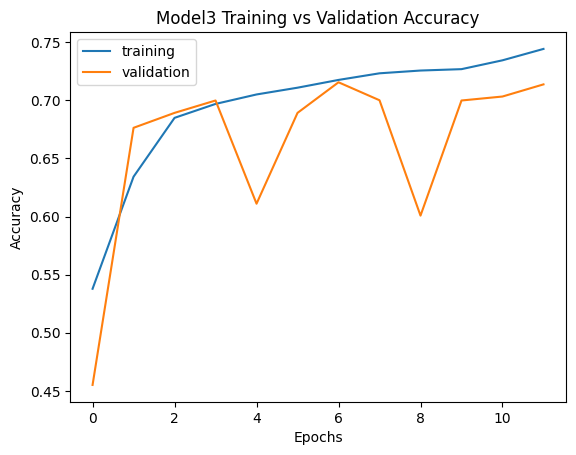

```python
plt.plot(history3.history['accuracy'])
plt.plot(history3.history['val_accuracy'])
plt.title('Model3 Training vs Validation Accuracy')
plt.xlabel('Epochs')
plt.ylabel('Accuracy')
plt.legend(['training','validation'])
```

### **Evaluating the Model on Test Set**

```python
model3.evaluate(test_data)
```

```
[903461.25, 0.7734375]
```

### **Plotting the Confusion Matrix for the chosen final model**

```
              precision    recall  f1-score   support

           0       0.93      0.78      0.85        32
           1       0.68      0.81      0.74        32
           2       0.70      0.72      0.71        32
           3       0.93      0.88      0.90        32

    accuracy                           0.80       128
   macro avg       0.81      0.80      0.80       128
weighted avg       0.81      0.80      0.80       128
```

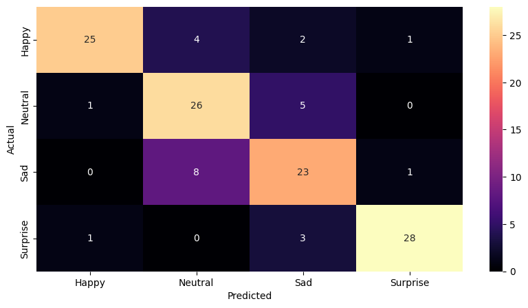

```python
y_pred=model3.predict(np.array(test_images))
y_pred=np.argmax(y_pred,axis=1)
y_true=np.argmax(np.array(test_labels),axis=1)

print(classification_report(y_true,y_pred))

f1_model3 = f1_score(y_true, y_pred, average='weighted')      #storing the f1 score of model3
accuracy_model3 = accuracy_score(y_true, y_pred)              #storing the accuracy of model3

cm=confusion_matrix(y_true,y_pred)
plt.figure(figsize=(10,5))
sns.heatmap(cm,cmap='magma',annot=True,xticklabels=['Happy','Neutral','Sad','Surprise'],yticklabels=['Happy','Neutral','Sad','Surprise'])
plt.xlabel('Predicted')
plt.ylabel('Actual')
```

### **Impact on Business**

A facial emotion recognition model with a 77% test accuracy can have high business utility in different sectors including education, health, safety and security,communications and much more. Being able to effectively predict human emotions can the pave way for easier human-machine interactions further leading towards technological breakthroughs.

### **Recommendations for implementation**

## **Design reccomendations**

A device consisting a minimum of 10 MP camera that can capture the face is recommended.

-Input image size must be 48 x 48. If not, it must be resized to fit this dimension as the model is designed to accept images of this size

-Dimensions of the image should be adjusted to account for batch_size=1. The image size would then be (1,48,48,1),ie,(batch_size=1 correction,48x48 image size,1-gray_scale). This is because our model accepts input in batches of 1.

-The predicted output of the model is in the form of an array of probabilities. This must be converted to the label using the below criteria using np.argmax() function or a substitute based on the platform:

-Index 0:Happy

-Index 1:Neutral

-Index 2:Sad

-Index 3:Surprise

## **Key Actionables for Stakeholders**

-Designing and implementing an interface: A user interface must be designed which will be able to get an image from a user and output the result returned by the model to the user interface. This needs to be done in collaboration with an IT team.

-Integrating the model into the desired application: Facial Emotion recognition systems are usually part of other larger systems. So, integrating the system into the larger system must be planned and executed. This could be a cloud platform, hand held devices or edge servers. This again needs to be done in collaboration with an IT team

-Ethical issues must be considered as we now have the capability to predict facial emotions without necessarily having the consent of the owners of the face. We need to make sure that the consent of a person is taken prior to being used as the input for the system

-End users must be given sufficient training and support for using the system if required.

-Feedback to be given for improvement of model performance as model development is a continuous process.

## **Risks and Challenges**

As the model has an accuracy of 77%, there will be times when there are incorrect predictions, precisely speaking, 23% of the time. Strategies must be in place to tackle such situations.

Low computation power: If the machine used to train the model has a very low computation power, it could lead to low model performance

## **Further Analysis and Associated problems**

The model accuracy can be increased if we train it on more images from the 'sad' and 'neutral' class.

A deeper fully connected network can also be implemented at the cost of computational resources.

Our final model deals only with 4 human emotions. Training the model on more emotions, for eg, 'Angry', 'Disgust',etc ,can expand its applications to more business sectors.

### Other findings

If the training data images are gray scale, you get better performance with grayscale input models

Transfer learning models VGG16, ResnetV2 and EfficientNet accept RGB inputs and don't perform well with grayscale images

Setting Shuffle=True improves training accuracy greatly

Increasing the number of Conv2D layers improves performance of the model

### **Testing the model on custom images with the help of a temporary GUI in Collab**

```python
# Load the model
model = load_model('/content/best_model3')    #accessing the model saved with the best performing weights based on val_accuracy
model.summary()
```

```
Model: "sequential"
_________________________________________________________________
 Layer (type)                Output Shape              Param #
=================================================================
 conv2d (Conv2D)             (None, 48, 48, 32)        544

 conv2d_1 (Conv2D)           (None, 48, 48, 32)        16416

 conv2d_2 (Conv2D)           (None, 48, 48, 64)        32832

 conv2d_3 (Conv2D)           (None, 48, 48, 64)        65600

 conv2d_4 (Conv2D)           (None, 48, 48, 64)        65600

 conv2d_5 (Conv2D)           (None, 48, 48, 64)        65600

 max_pooling2d (MaxPooling2  (None, 24, 24, 64)        0
 D)

 conv2d_6 (Conv2D)           (None, 24, 24, 128)       131200

 conv2d_7 (Conv2D)           (None, 24, 24, 128)       262272

 conv2d_8 (Conv2D)           (None, 24, 24, 128)       262272

 conv2d_9 (Conv2D)           (None, 24, 24, 128)       262272

 max_pooling2d_1 (MaxPoolin  (None, 12, 12, 128)       0
 g2D)

 conv2d_10 (Conv2D)          (None, 12, 12, 256)       524544

 conv2d_11 (Conv2D)          (None, 12, 12, 256)       1048832

 conv2d_12 (Conv2D)          (None, 12, 12, 256)       1048832

 conv2d_13 (Conv2D)          (None, 12, 12, 256)       1048832

 max_pooling2d_2 (MaxPoolin  (None, 6, 6, 256)         0
 g2D)
```

[output cut: 9 more lines]

```

 dropout_1 (Dropout)         (None, 32)                0

 batch_normalization_1 (Bat  (None, 32)                128
 chNormalization)

 dense_1 (Dense)             (None, 32)                1056

 dense_2 (Dense)             (None, 4)                 132

=================================================================
Total params: 5168772 (19.72 MB)
Trainable params: 5150276 (19.65 MB)
Non-trainable params: 18496 (72.25 KB)
_________________________________________________________________
```